# Formulas in R

DSCI 632: Statistics for Data Science

Peter Ralph

# Set-up

## Example data

Continuing with the “pumpkin data”:

```r
(pumpkins <- read.table("data/pumpkins.tsv"))
```

```
##     fertilizer    water plot plant    weight       condition mean_weight
## 1          low no water    1     1  4.439524    low,no water           5
## 2       medium no water    1     1  6.769823 medium,no water           7
## 3         high no water    1     1 10.558708   high,no water           9
## 4          low    water    1     1  6.070508       low,water           6
## 5       medium    water    1     1  8.129288    medium,water           8
## 6         high    water    1     1 16.715065      high,water          15
## 7          low no water    2     1  5.460916    low,no water           5
## 8       medium no water    2     1  5.734939 medium,no water           7
## 9         high no water    2     1  8.313147   high,no water           9
## 10         low    water    2     1  5.554338       low,water           6
## 11      medium    water    2     1  9.224082    medium,water           8
## 12        high    water    2     1 15.359814      high,water          15
## 13         low no water    3     1  5.400771    low,no water           5
## 14      medium no water    3     1  7.110683 medium,no water           7
```

[output cut: 106 more lines]

# Formulas

## Anatomy of a formula

```
  weight ~ fertilizer + water
```

is read something like

> mean weight is determined by additive effects of fertlizer and of water

$$\begin{equation}\begin{split}
y &\sim x \qquad \text{means} \\
y &= a + b x + \text{(mean-zero noise)} .
\end{split}\end{equation}$$

## Intercepts

The intercept is included implicitly, so these are equivalent:

```
  weight ~ fertilizer + water
  weight ~ 1 + fertilizer + water
```

… so if you *don’t* want an intercept, do

```
  weight ~ 0 + fertilizer + water
```

## Interactions

To assign an effect to each element of a *crossed* design, use `:`, e.g.

```
  weight ~ fertilizer + water + fertilizer:water
```

which is the same as

```
  weight ~ fertilizer * water
```

since lower-order effects are included implicitly.

## A translation table

Trickier things:

- `1` : an intercept
- `0` : but not an intercept
- `-` : but not
- `.` : all columns not otherwise in the formula
- `x/y` : `x`, and `y` nested within `x` (same as `x + x:y`)

## The secret to formulas

If you want to know what a formula is *really* doing, look at its `model.matrix( )`, whose columns correspond to the coefficients of the resulting model.

```r
model.matrix(~ fertilizer, data=pumpkins)
```

```
##     (Intercept) fertilizerlow fertilizermedium
## 1             1             1                0
## 2             1             0                1
## 3             1             0                0
## 4             1             1                0
## 5             1             0                1
## 6             1             0                0
## 7             1             1                0
## 8             1             0                1
## 9             1             0                0
## 10            1             1                0
## 11            1             0                1
## 12            1             0                0
## 13            1             1                0
## 14            1             0                1
```

[output cut: 111 more lines]

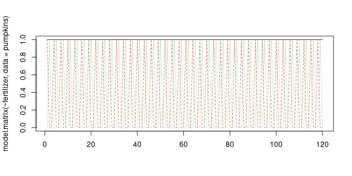

```r
matplot(
    model.matrix(~ fertilizer, data=pumpkins),
    type='l')
```

```r
model.matrix(~ fertilizer + water, data=pumpkins)
```

```
##     (Intercept) fertilizerlow fertilizermedium waterwater
## 1             1             1                0          0
## 2             1             0                1          0
## 3             1             0                0          0
## 4             1             1                0          1
## 5             1             0                1          1
## 6             1             0                0          1
## 7             1             1                0          0
## 8             1             0                1          0
## 9             1             0                0          0
## 10            1             1                0          1
## 11            1             0                1          1
## 12            1             0                0          1
## 13            1             1                0          0
## 14            1             0                1          0
```

[output cut: 114 more lines]

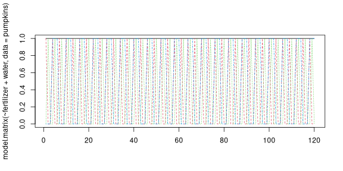

```r
matplot(
    model.matrix(~ fertilizer + water, data=pumpkins),
    type='l')
```

```r
model.matrix(~ 0 + fertilizer * water, data=pumpkins)
```

```
##     fertilizerhigh fertilizerlow fertilizermedium waterwater fertilizerlow:waterwater fertilizermedium:waterwater
## 1                0             1                0          0                        0                           0
## 2                0             0                1          0                        0                           0
## 3                1             0                0          0                        0                           0
## 4                0             1                0          1                        1                           0
## 5                0             0                1          1                        0                           1
## 6                1             0                0          1                        0                           0
## 7                0             1                0          0                        0                           0
## 8                0             0                1          0                        0                           0
## 9                1             0                0          0                        0                           0
## 10               0             1                0          1                        1                           0
## 11               0             0                1          1                        0                           1
## 12               1             0                0          1                        0                           0
## 13               0             1                0          0                        0                           0
## 14               0             0                1          0                        0                           0
```

[output cut: 114 more lines]

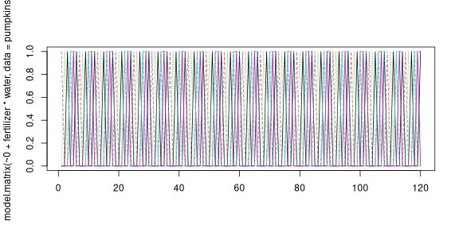

```r
matplot(
    model.matrix(~ 0 + fertilizer * water, data=pumpkins),
    type='l')
```

## Note:

For fine control of factors in linear models, either

- `relevel()` them, or
- manually set their `contrasts()`.

## Exercise:

Make formulas that give you estimates of

1. A global mean ($\mu$), two fertilizer effects ($\alpha_\text{medium}$ and $\alpha_\text{high}$), and one water effect ($\beta_\text{water}$).
2. Three fertilizer effects ($\alpha_\text{low}$, $\alpha_\text{medium}$ and $\alpha_\text{high}$), and one water effect ($\beta_\text{water}$).
3. Two fertilizer effects ($\alpha_\text{medium}$ and $\alpha_\text{high}$), and two water effect ($\beta_\text{no water}$ and $\beta_\text{water}$).
4. A single mean for each of the six conditions ($\gamma_\text{high, water}$, $\gamma_\text{medium, water}$, $\gamma_\text{low, water}$, $\gamma_\text{high, no water}$, $\gamma_\text{medium, no water}$, $\gamma_\text{low, no water}$).

*Data:* [pumkpins.tsv](https://github.com/UO-Biostats/UO_ABS/raw/master/CLASS_MATERIALS/Lectures/data/pumpkins.tsv)

## Example:

1. A global mean ($\mu$), two fertilizer effects ($\alpha_\text{medium}$ and $\alpha_\text{high}$), and one water effect ($\gamma_\text{water}$).

*Example:*

```r
summary(lm(weight ~ fertilizer + water, data=pumpkins))
```

```
##
## Call:
## lm(formula = weight ~ fertilizer + water, data = pumpkins)
##
## Residuals:
##     Min      1Q  Median      3Q     Max
## -3.2699 -1.1239 -0.0396  1.0029  3.5422
##
## Coefficients:
##                  Estimate Std. Error t value Pr(>|t|)
## (Intercept)       10.7212     0.2773  38.662  < 2e-16 ***
## fertilizerlow     -6.2486     0.3396 -18.398  < 2e-16 ***
## fertilizermedium  -4.5462     0.3396 -13.386  < 2e-16 ***
## waterwater         2.4517     0.2773   8.841 1.22e-14 ***
## ---
## Signif. codes:  0 '***' 0.001 '**' 0.01 '*' 0.05 '.' 0.1 ' ' 1
##
## Residual standard error: 1.519 on 116 degrees of freedom
## Multiple R-squared:  0.7914, Adjusted R-squared:  0.786
## F-statistic: 146.7 on 3 and 116 DF,  p-value: < 2.2e-16
```

Change the reference level:

```r
pumpkins$fertilizer <- factor(pumpkins$fertilizer, levels=c("low", "medium", "high"))
pumpkins$water <- factor(pumpkins$water, levels=c("no water", "water"))
```

Three fertilizer effects ($\alpha_\text{low}$, $\alpha_\text{medium}$ and $\alpha_\text{high}$), and one water effect ($\beta_\text{water}$).

```r
lm(weight ~ 0 + fertilizer + water, data=pumpkins) |> summary()
```

```
##
## Call:
## lm(formula = weight ~ 0 + fertilizer + water, data = pumpkins)
##
## Residuals:
##     Min      1Q  Median      3Q     Max
## -3.2699 -1.1239 -0.0396  1.0029  3.5422
##
## Coefficients:
##                  Estimate Std. Error t value Pr(>|t|)
## fertilizerlow      4.4726     0.2773  16.129  < 2e-16 ***
## fertilizermedium   6.1750     0.2773  22.268  < 2e-16 ***
## fertilizerhigh    10.7212     0.2773  38.662  < 2e-16 ***
## waterwater         2.4517     0.2773   8.841 1.22e-14 ***
## ---
## Signif. codes:  0 '***' 0.001 '**' 0.01 '*' 0.05 '.' 0.1 ' ' 1
##
## Residual standard error: 1.519 on 116 degrees of freedom
## Multiple R-squared:  0.9723, Adjusted R-squared:  0.9713
## F-statistic:  1016 on 4 and 116 DF,  p-value: < 2.2e-16
```

Two fertilizer effects ($\alpha_\text{medium}$ and $\alpha_\text{high}$), and two water effect ($\beta_\text{no water}$ and $\beta_\text{water}$).

```r
lm(weight ~ water + fertilizer - 1, data=pumpkins) |> summary()
```

```
##
## Call:
## lm(formula = weight ~ water + fertilizer - 1, data = pumpkins)
##
## Residuals:
##     Min      1Q  Median      3Q     Max
## -3.2699 -1.1239 -0.0396  1.0029  3.5422
##
## Coefficients:
##                  Estimate Std. Error t value Pr(>|t|)
## waterno water      4.4726     0.2773  16.129  < 2e-16 ***
## waterwater         6.9243     0.2773  24.970  < 2e-16 ***
## fertilizermedium   1.7024     0.3396   5.013 1.95e-06 ***
## fertilizerhigh     6.2486     0.3396  18.398  < 2e-16 ***
## ---
## Signif. codes:  0 '***' 0.001 '**' 0.01 '*' 0.05 '.' 0.1 ' ' 1
##
## Residual standard error: 1.519 on 116 degrees of freedom
## Multiple R-squared:  0.9723, Adjusted R-squared:  0.9713
## F-statistic:  1016 on 4 and 116 DF,  p-value: < 2.2e-16
```

A single mean for each of the six conditions ($\gamma_\text{high, water}$, $\gamma_\text{medium, water}$, $\gamma_\text{low, water}$, $\gamma_\text{high, no water}$, $\gamma_\text{medium, no water}$, $\gamma_\text{low, no water}$).

```r
lm(weight ~ 0 + water : fertilizer, data=pumpkins) |> summary()
```

```
##
## Call:
## lm(formula = weight ~ 0 + water:fertilizer, data = pumpkins)
##
## Residuals:
##      Min       1Q   Median       3Q      Max
## -2.19455 -0.56686 -0.04693  0.46657  2.08451
##
## Coefficients:
##                                Estimate Std. Error t value Pr(>|t|)
## waterno water:fertilizerlow      5.2757     0.2002   26.35   <2e-16 ***
## waterwater:fertilizerlow         6.1212     0.2002   30.57   <2e-16 ***
## waterno water:fertilizermedium   7.0845     0.2002   35.38   <2e-16 ***
## waterwater:fertilizermedium      7.7173     0.2002   38.54   <2e-16 ***
## waterno water:fertilizerhigh     9.0087     0.2002   44.99   <2e-16 ***
## waterwater:fertilizerhigh       14.8854     0.2002   74.34   <2e-16 ***
## ---
## Signif. codes:  0 '***' 0.001 '**' 0.01 '*' 0.05 '.' 0.1 ' ' 1
##
## Residual standard error: 0.8955 on 114 degrees of freedom
## Multiple R-squared:  0.9905, Adjusted R-squared:   0.99
## F-statistic:  1986 on 6 and 114 DF,  p-value: < 2.2e-16
```